# Modele COVID-19 Recognition

## Modele COVID-19 Recognition :

## 3DNI2 : Projet tutoré Développement GL

### Import des biblio :

```python
import glob
import shutil
import cv2
import os
from PIL import Image
import seaborn as sns
import numpy as np
from matplotlib import pyplot as plt
import tensorflow as tf
from tensorflow.keras.layers import *
from tensorflow.keras.models import *
from tensorflow.keras.preprocessing import *
from keras.applications.vgg16 import VGG16
from keras import layers

# from skimage.feature import local_binary_pattern

import warnings
# Ignore waring
warnings.filterwarnings('ignore')
```

### Ce code est destiné à charger un ensemble d'images de radiographies de patients atteints de COVID-19 depuis un répertoire, à les redimensionner et à leur attribuer des étiquettes.

#### X : contiendra toutes les images sous forme de tableaux de pixels, chacune ayant été redimensionnée à 128x128 pixels.

#### y : contiendra uniquement des 1, indiquant que toutes les images sont étiquetées comme appartenant à la classe 'Covid'.

```python
name_list = glob.glob("C:/Users/yosser/OneDrive/Bureau/3DNI/Projets/developpement/COVID-19_Radiography_Dataset/COVID/images/*")

labels = ['NORMAL', 'Covid']

#Load the training images and labels
X= []
y = []
for name in name_list:
  y.append(1)
  img = cv2.imread(name)
  img = tf.keras.preprocessing.image.img_to_array(img)
  img = cv2.resize(img,(128,128))

  X.append((img))
len(X)
```

```
3616
```

### ici , on fait le meme démarche pour charger les images des patients normal

#### x: contiendra toutes les images sous forme de tableaux de pixels, chacune ayant été redimensionnée à 128x128 pixels.

#### y: contiendra des 1(indique classe COVID) , et des 0 (indique classe Normal)

```python
name_list = glob.glob("C:/Users/yosser/OneDrive/Bureau/3DNI/Projets/developpement/COVID-19_Radiography_Dataset/Normal/images/*")

for name in name_list:
  y.append(0)
  img = cv2.imread(name)
  img = tf.keras.preprocessing.image.img_to_array(img)
  img = cv2.resize(img,(128,128))
  X.append((img))
len(X)
```

```
7841
```

### Conversion de X et Y en deux tableaux NumPy et les redimensionner :

##### Cela permet de faciliter le traitement numérique, car NumPy est optimisé pour les opérations sur les tableaux.

```python
X = np.array(X)
y = np.array(y).reshape(-1,1)
```

### Affichage des informations sur les tableaux X et y après leur conversion en tableaux NumPy.

```python
print(len(X))
print(X.shape)
print(y.shape)
```

```
7841
(7841, 128, 128, 3)
(7841, 1)
```

### Division des données d'images et d'étiquettes en trois parties : un ensemble d'entraînement (90%), un ensemble de validation (2 %) et un ensemble de test(8%) .

```python
from sklearn.model_selection import train_test_split
X_train, X_test,y_train, y_test = train_test_split(X, y, test_size=0.1, random_state=42)
X_test, X_val, y_test, y_val = train_test_split(X_test, y_test, test_size=0.2, random_state=42)

print( X_train.shape) #Train
print(X_val.shape)    #validation
print( X_test.shape)  #Test
```

```
(7056, 128, 128, 3)
(157, 128, 128, 3)
(628, 128, 128, 3)
```

### Normalisation des images : (255 pixels)

```python
X_train = X_train /255
X_test_scaled = X_test / 255
X_val = X_val/255
```

### VGG16 : C'est une architecture de réseau de neurones convolutifs (CNN) pré-entraînée, célèbre pour ses performances en classification d'images.

```python
base_model = VGG16(weights='imagenet', include_top=False, input_shape=(128,128, 3))


for layer in base_model.layers:
    layer.trainable = False

model = Sequential()
model.add(base_model)
model.add(Flatten())
model.add(Dense(1024))
model.add(Activation("relu"))
model.add(Dense(512))
model.add(Activation("relu"))
model.add(Dense(1))
model.add(Activation("sigmoid"))
# Summary model
model.summary()
```

```
Model: "sequential"
_________________________________________________________________
 Layer (type)                Output Shape              Param #
=================================================================
 vgg16 (Functional)          (None, 4, 4, 512)         14714688

 flatten (Flatten)           (None, 8192)              0

 dense (Dense)               (None, 1024)              8389632

 activation (Activation)     (None, 1024)              0

 dense_1 (Dense)             (None, 512)               524800

 activation_1 (Activation)   (None, 512)               0

 dense_2 (Dense)             (None, 1)                 513

 activation_2 (Activation)   (None, 1)                 0

=================================================================
Total params: 23,629,633
Trainable params: 8,914,945
Non-trainable params: 14,714,688
_________________________________________________________________
```

### Configuration et entraînement d'un modèle d'apprentissage automatique en utilisant TensorFlow et Keras.

```python
from tensorflow.keras.callbacks import EarlyStopping
learning_rate = 0.00001  # taux d'apprentissage
decay_steps = 10         # le taux d'apprentissage sera ajusté toutes les 10 époques
decay_rate = 1            # le facteur par lequel le taux d'apprentissage doit être réduit

# Initialisation de l'ordonnanceur de taux d'apprentissage
lr_scheduler = tf.keras.optimizers.schedules.ExponentialDecay(learning_rate, decay_steps, decay_rate)
optimizer1 = tf.keras.optimizers.Adam(learning_rate = lr_scheduler)
early_stop = EarlyStopping(monitor='val_loss', patience=5, restore_best_weights=True)

model.compile(optimizer = optimizer1, loss = 'binary_crossentropy',metrics =['accuracy'])
# Entraînement du modèle
history = model.fit(X_train,y_train,batch_size = 32, epochs =15,validation_data =(X_val, y_val), callbacks=[early_stop])
```

## Visualisation de l'exactitude et la perte du modèle :

#### Remarque: Une diminution de la perte indique que le modèle apprend et s'améliore, tandis qu'une perte stagnante ou en augmentation peut indiquer un surapprentissage.

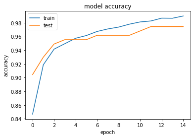

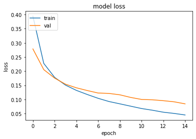

```python
from matplotlib import pyplot  as plt
plt.plot(history.history['accuracy'])
plt.plot(history.history['val_accuracy'])
plt.title('model accuracy')
plt.ylabel('accuracy')
plt.xlabel('epoch')
plt.legend(['train','test'],loc ='upper left')
plt.show()
#summarize history for loss
plt.plot(history.history['loss'])
plt.plot(history.history['val_loss'])
plt.title('model loss')
plt.ylabel('loss')
plt.xlabel('epoch')
plt.legend(['train','val'],loc ='upper left')
plt.show()
```

## Enregistrement du modèle pour l'utiliser aprés avec notre interface web

```python
model.save('C:/Users/yosser/OneDrive/Bureau/3DNI/Projets/developpement/model1.h5')
```

### chargement du notre modèle de deep learning déjà entraîné et sauvegardé au format HDF5 :

```python
model1 = load_model('C:/Users/yosser/OneDrive/Bureau/3DNI/Projets/developpement/model1.h5')  #
```

### Utilisation de notre modele pour faire la prediction :

#### Les sorties de model1.predict() sont des valeurs comprises entre 0 et 1, représentant la probabilité que l'échantillon appartienne à la classe positive (ici, COVID-19).

#### Si la probabilité est supérieure ou égale à 0,5, la classe est considérée comme 1 (COVID).

#### Si la probabilité est inférieure à 0,5, la classe est considérée comme 0 (Normal).

```python
y_hat = model1.predict(X_test_scaled) #  prédiction sur les données de test
def predict(y_hat):
    y_hat[y_hat >= 0.5] =1
    y_hat[y_hat<0.5] =0
    return y_hat
y_pred = predict(y_hat)             # Calcul de la précision (accuracy)
from sklearn.metrics import accuracy_score
accuracy = accuracy_score(y_test, y_pred)
print(accuracy)
result= []
real_result = []
for i in y_pred:                # Conversion des prédictions en étiquettes de texte (Label)
    if i==0:
        result.append('Normal')
    if i==1:
        result.append('Covid')
for i in y_pred:
    if i==0:
        real_result.append('Normal')
    if i==1:
        real_result.append('Covid')
```

```
0.9665605095541401
```

#### La precision est 0.9665605095541401

### Utilisation des fonctions de la bibliothèque Scikit-learn pour évaluer les performances d'un modèle de machine learning.

```python
from sklearn.metrics import confusion_matrix, classification_report, accuracy_score
labels = ['Covid', 'Normal']
report = classification_report(y_test, y_pred, target_names=labels)
print(report)
accuracy = accuracy_score(y_test, y_pred)

print(f"Accuracy: {accuracy}")
```

[output not shown]

### Affichage de matrice de confusion + Heatmap :

```
[[334  10]
 [ 11 273]]
```

[figure not shown]

```python
cm = confusion_matrix(y_test, y_pred)     #  Calcul de la matrice de confusion
print(cm)
sns.heatmap(cm, annot=True, fmt='d', cmap='Blues') #Affichage de heatmap


tick_labels = ['Covid', 'Normal']
plt.xticks(np.arange(len(tick_labels)) + 0.5, tick_labels)
plt.yticks(np.arange(len(tick_labels)) + 0.5, tick_labels)

plt.xlabel('Predicted')
plt.ylabel('True')
plt.title('Confusion Matrix')
plt.show()
```

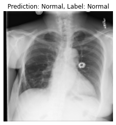

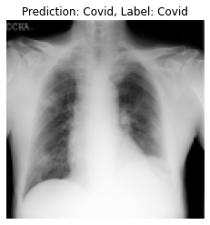

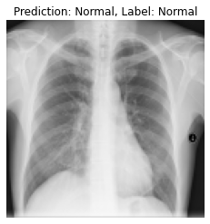

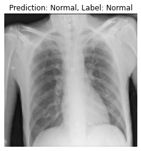

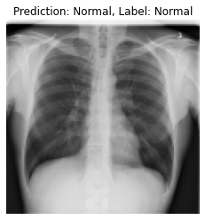

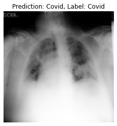

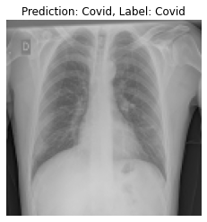

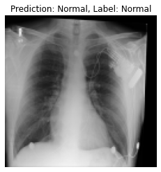

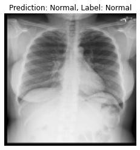

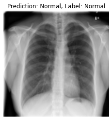

```python
import matplotlib.pyplot as plt

def show_image_with_prediction(image_array, prediction, label):
    plt.imshow(image_array)
    plt.axis('off')
    plt.title(f'Prediction: {prediction}, Label: {label}')
    plt.show()

# In this case, we're only showing the first 10 images
image_arrays = X_test[:10]  # Select only the first 10 images
predictions = result[:10]    # Select the first 10 predictions
labels = real_result[:10]    # Select the first 10 actual labels

# Display 10 images with predicted and actual labels
for image_array, prediction, label in zip(image_arrays, predictions, labels):
    show_image_with_prediction(image_array / 255, prediction, label)
```

```python
name_list = glob.glob("C:/Users/yosser/OneDrive/Bureau/3DNI/Projets/developpement/Covid/COVID-19_Radiography_Dataset/Prediction_Input/*")

#Load the training images and labels
X_input= []
for name in name_list:
  img = cv2.imread(name)
  img = tf.keras.preprocessing.image.img_to_array(img)
  img = cv2.resize(img,(128,128))

  X_input.append((img))
```

#### Apres on va charger notre modèle, préparer des images, prédire leur classe, et convertir les probabilités en étiquettes.

```python
X_input=np.array(X_input)
X_input = X_input/255
model1 = load_model('C:/Users/yosser/OneDrive/Bureau/3DNI/Projets/developpement/model1.h5')
y_hat = model1.predict(X_input)
y_pred = predict(y_hat)
```

```python
result_pred =[]
for i in y_pred:
    if i==0:
        result_pred.append('Normal')
    if i==1:
        result_pred.append('Covid')

#ce code parcourt les prédictions numériques (0 ou 1) dans y_pred, et pour chaque prédiction,
#il convertit les valeurs numériques en étiquettes de classe ("Normal" ou "Covid") et les ajoute à la liste result_pred.
#À la fin de cette boucle, result_pred contiendra les étiquettes correspondantes pour toutes les prédictions effectuées par
#le modèle.
```

### Visualisation et Sauvegarde des Prédictions d'Images pour la Détection de COVID-19 :

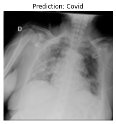

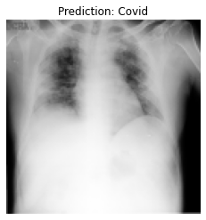

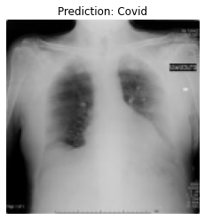

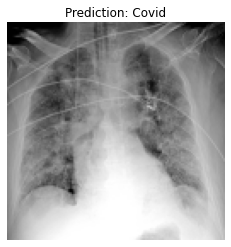

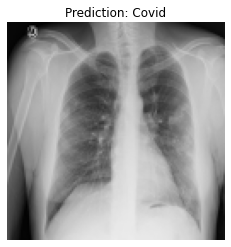

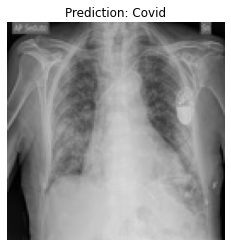

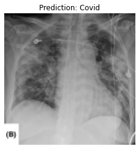

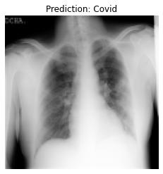

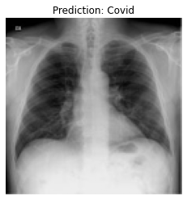

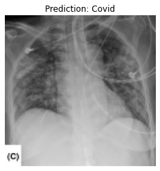

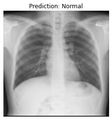

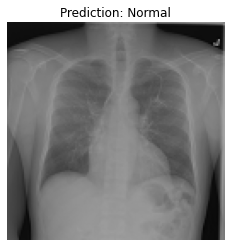

[8 more figures not shown]

```python
import matplotlib.pyplot as plt
import os

def show_image_with_prediction(image_array, prediction):
    plt.imshow(image_array)
    plt.axis('off')
    plt.title(f'Prediction: {prediction}')
    plt.show()

image_arrays = X_input
predictions = result_pred
for image_array, prediction in zip(image_arrays, predictions):
    show_image_with_prediction(image_array, prediction)
output_dir = "C:/Users/yosser/OneDrive/Bureau/3DNI/Projets/developpement/Resultat"
if not os.path.exists(output_dir):
    os.makedirs(output_dir)
for i, (image_array, prediction) in enumerate(zip(image_arrays, predictions)):
    filename = f"image_{i}_prediction_{prediction}.jpg"
    file_path = os.path.join(output_dir, filename)
    plt.savefig(file_path)
```